# Coursework_MAP501_2021

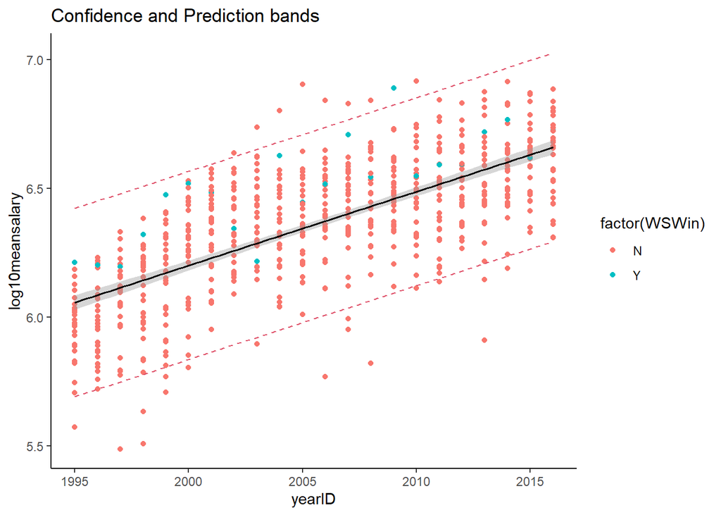

```r
salconf <- confint(linmod1)

salpred <- predict(linmod1, interval = "prediction") %>%
            as.tibble(salpred)

pplot <- cbind(logdata, salpred)


ggplot(pplot, aes(x = yearID ,y = log10(meansalary))) +
  geom_point(aes(colour = factor(WSWin)))+
  geom_smooth(formula = y ~ x, method = lm , color="black", size = 0.7) +
  geom_line(aes(y = lwr), color = 2, lty = 2) +
  geom_line(aes(y = upr), color = 2, lty = 2) +
  labs(x="yearID",y="log10meansalary",title="Confidence and Prediction bands")+
  theme_classic()
```

The confidence Interval for intercept is between -55.76 to -46.68 which is quite large. On the other hand, we are more confident for yearID because it should lie between 0.026 and 0.030. This means that for each additional year, we expect on average between 0.026 and 0.030 increase in log10 of the meansalary.

5. [1 + 1 points] Investigate the points that appear above the top prediction band. What team or teams do they relate to?

```r
pplot %>%
  filter(log10meansalary >= upr) %>%
  select(yearID,name,log10meansalary,lwr,upr)
```

| yearID | name | log10meansalary | lwr | upr |
| --- | --- | --- | --- | --- |
| 2002 | New York Yankees | 6.637726 | 5.892547 | 6.623120 |
| 2003 | New York Yankees | 6.736823 | 5.921302 | 6.651788 |
| 2004 | New York Yankees | 6.802877 | 5.950043 | 6.680470 |
| 2005 | New York Yankees | 6.903730 | 5.978769 | 6.709166 |
| 2006 | New York Yankees | 6.842126 | 6.007482 | 6.737876 |
| 2007 | New York Yankees | 6.829899 | 6.036180 | 6.766601 |
| 2008 | New York Yankees | 6.840727 | 6.064865 | 6.795339 |
| 2009 | New York Yankees | 6.889192 | 6.093536 | 6.824091 |
| 2010 | New York Yankees | 6.916630 | 6.122192 | 6.852857 |

Only the team New York Yankees is above of the top of the prediction band. Moreover, we can see that New York Yankees is one of the teams that won the world series which we saw before, teams with higher salary as here NYY are more likely to win the world series.

# 3. Multiple regression for Count Data

1. [2 + 2 points] Create a histogram of the number of runs scored for players in the Playerdata dataset so each bar is a single value (0,1,2 runs, etc). Next create a histogram of the number of runs for all players who have had a hit. Give a domain-based and a data-based reason why it is more reasonable to create a Poisson data for the second set than the first.

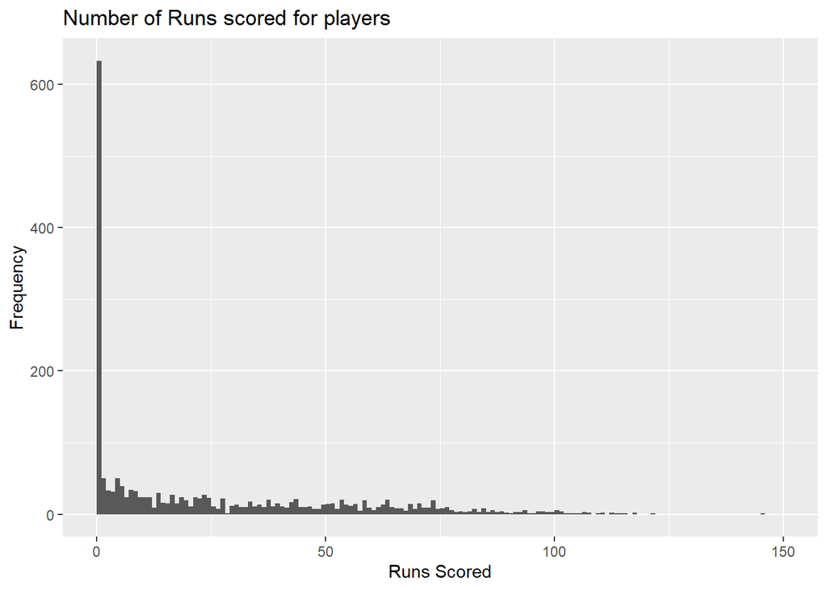

```r
hist1 <-
    ggplot(Playerdata,aes(R)) +
    geom_histogram(binwidth = 6, breaks=seq(0,150,1)) +
    labs(x = "Runs Scored", y = "Frequency", title ="Number of Runs scored for players")
hist1
```

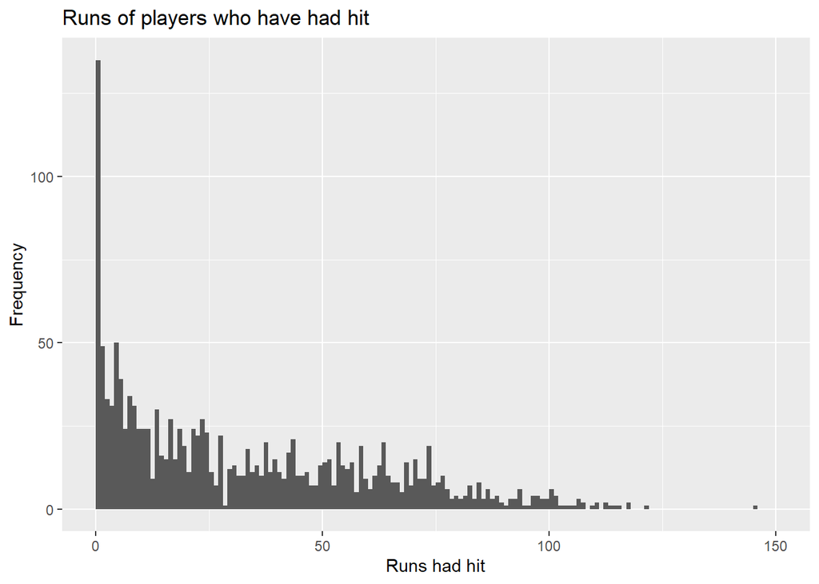

```r
hist2 <-
  Playerdata %>%
    mutate(RunwithHit = ifelse(H == "0",0,1)) %>%
    filter(RunwithHit == "1") %>%
    ggplot(aes(R)) +
    geom_histogram(binwidth = 6, breaks=seq(0,150,1)) +
    labs(x = "Runs had hit", y = "Frequency", title ="Runs of players who have had hit")
hist2
```

Domain-based reason -> Only the players who have had hit the ball can score a run

Data-based reason -> The count of the second set is a number that can’t be fraction (hits) whereas the first one is a number that can be a fraction.

So the Statistical analysis is that to find a balance between these two we use Poisson which for only players who have a hit.

2. [3 + 0 points] Create a new dataset, OnBase of all players who have had at least one hit. Transform yearID to a factor. Construct a Poisson model, glm1, of the number of runs as a function of the number of hits, the year as a factor, position played and player height and age.

```r
OnBase <- Playerdata %>%
  filter(H >= 1) %>%
  mutate(yearf = as.factor(yearID))


glm1 <- glm(R ~ H + yearf + POS + height + age ,data=OnBase,family="poisson")

summary(glm1)
```

```
Call:
glm(formula = R ~ H + yearf + POS + height + age, family = "poisson",
    data = OnBase)

Deviance Residuals:
    Min       1Q   Median       3Q      Max
-9.1745  -1.5840  -0.2634   1.0653   7.9508

Coefficients:
              Estimate Std. Error z value Pr(>|z|)
(Intercept)  2.494e+00  1.692e-01  14.743  < 2e-16 ***
H            1.285e-02  8.953e-05 143.571  < 2e-16 ***
yearf2015    2.231e-02  9.285e-03   2.402  0.01629 *
POS2B       -1.152e-02  1.671e-02  -0.689  0.49063
POS3B        5.319e-03  1.574e-02   0.338  0.73535
POSC        -6.297e-02  2.074e-02  -3.036  0.00239 **
POSOF        6.322e-02  1.319e-02   4.792 1.65e-06 ***
POSP        -1.171e+00  3.710e-02 -31.556  < 2e-16 ***
POSSS       -1.123e-02  1.754e-02  -0.640  0.52207
height      -3.584e-03  2.241e-03  -1.599  0.10982
age          4.693e-03  1.202e-03   3.904 9.47e-05 ***
---
Signif. codes:  0 '***' 0.001 '**' 0.01 '*' 0.05 '.' 0.1 ' ' 1

(Dispersion parameter for poisson family taken to be 1)

    Null deviance: 38805.9  on 1481  degrees of freedom
Residual deviance:  5695.8  on 1471  degrees of freedom
AIC: 12616

Number of Fisher Scoring iterations: 5
```

3. [2 + 4 points] Find the p-value for each of the predictor variables in this model using a Likelihood Ratio Test. What hypothesis does each p-value test, and what mathematically does a p-value tell you about a variable? Use this definition to say what is meant by the p-value associated to POS and to the p-value associated to height.

```r
A <- Anova(glm1)
A
```

|  | LR Chisq | Df | Pr(>Chisq) |
| --- | --- | --- | --- |
| H | 21541.043502 | 1 | 0.000000e+00 |
| yearf | 5.775780 | 1 | 1.624851e-02 |
| POS | 1584.473151 | 6 | 0.000000e+00 |
| height | 2.555022 | 1 | 1.099443e-01 |
| age | 15.193211 | 1 | 9.705174e-05 |

The H hypothesis is if the Hits has an effect on the Score of Runs. Since the p-value (< 2.2e-16) is smaller than 0.05, this means that the predictor is statistically significant and with large coefficient which means that if we change it it will make a big difference in Run. There is a 0.00000000000000022, chance of observing this at random.

The yearf hypothesis is if the years has an effect on the Score of Runs. Since the p-value (0.01625) is smaller than 0.05, this means that the predictor is significant and with large coefficient which means that if we change it it will make a big difference in R. There is a 0.01625 chance of observing this at random.

The POS hypothesis is if the Position of the players has an effect on the Score of Runs. Since the p-value (< 2e-16) is smaller than 0.05, this means that the predictor is important, significant and with large coefficient which means that if we change it it will make a big difference in R. There is a 0.00000000000000022, chance of observing this at random.

The height hypothesis is if the height of players has an effect on the Score of Runs. Since the p-value (0.10994) is greater than 0.05, this means that the predictor is not important and with small coefficient which means that if we change it it will not make a big difference at all in R. There is a 0.10994 chance of observing this at random.

The age hypothesis is if the age of players has an effect on the Score of Runs. Since the p-value (9.705e-05) is smaller than 0.05, this means that the predictor is important, significant and with large coefficient which means that if we change it it will make a big difference in R. There is a 9.705e-05 chance of observing this at random.

4. [1 + 8 points] State the assumptions of Poisson models and check these where possible.

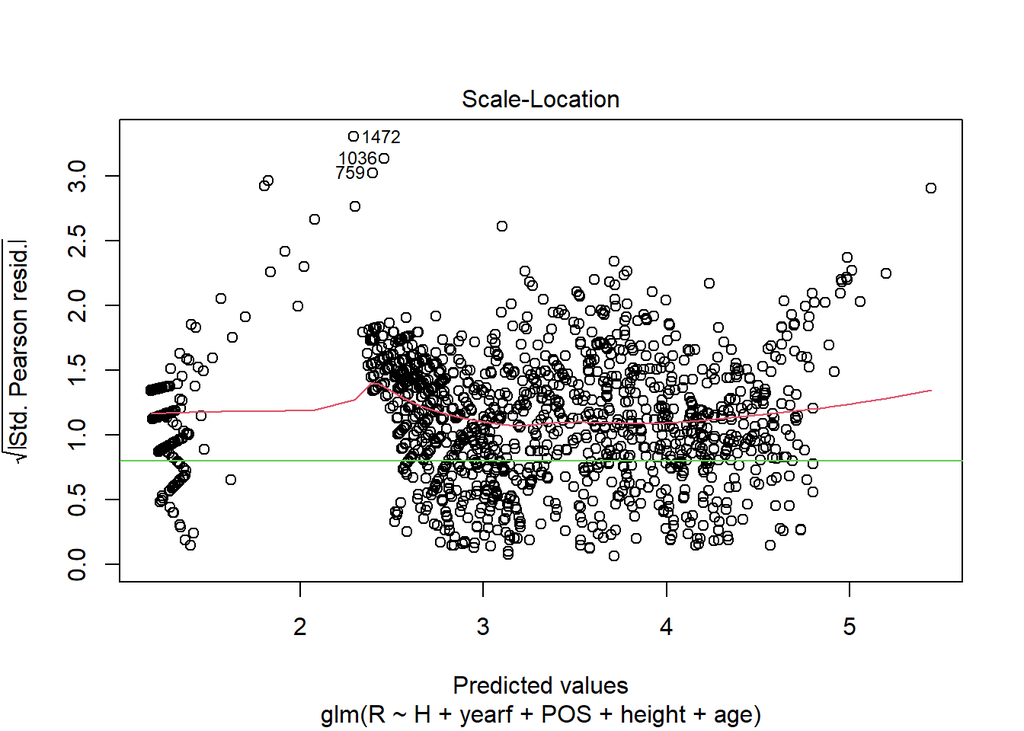

```r
plot(glm1,which=3)
abline(h=0.8,col=3)
```

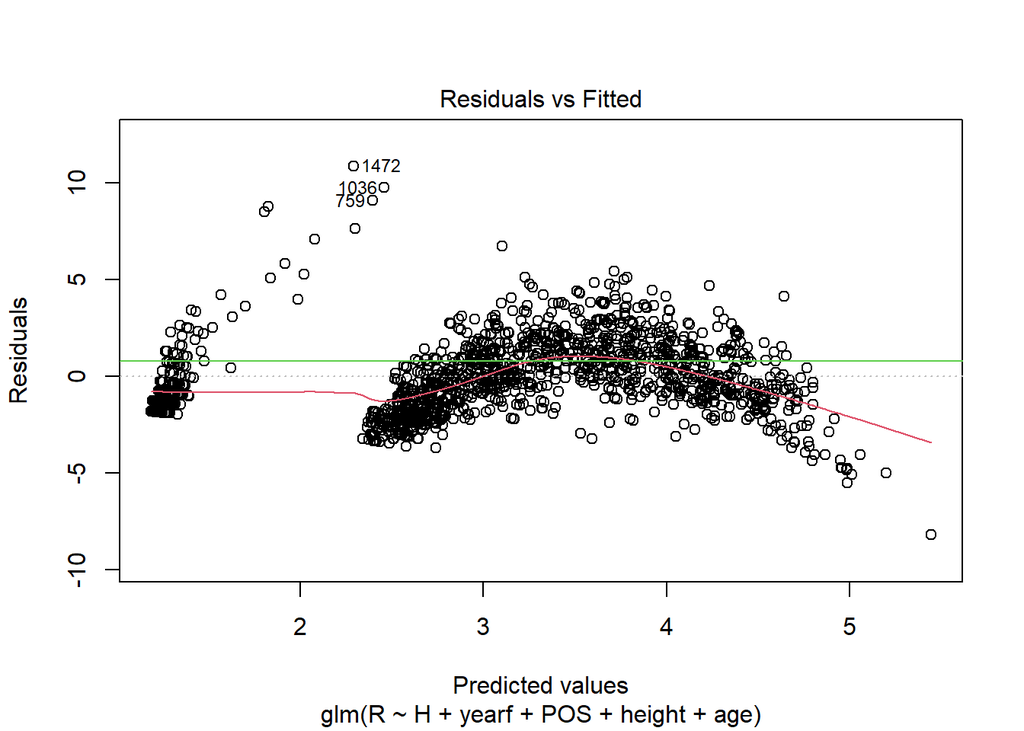

```r
plot(glm1,which=1)
abline(h=0.8,col=3)
```

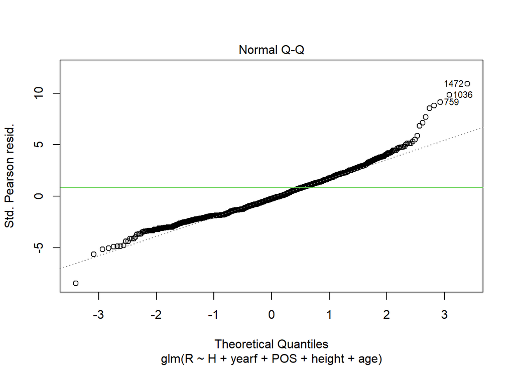

```r
plot(glm1,which=2)
abline(h=0.8,col=3)
```

```r
glm2 <-
  glmer(R ~ H + yearf + POS + height + age + (1|teamID) ,data=OnBase,family="poisson")


summary(glm2)


teameffect <- ranef(glm2)$teamID
teameffect
```

```
Generalized linear mixed model fit by maximum likelihood (Laplace
  Approximation) [glmerMod]
 Family: poisson  ( log )
Formula: R ~ H + yearf + POS + height + age + (1 | teamID)
   Data: OnBase

     AIC      BIC   logLik deviance df.resid
 12286.4  12350.1  -6131.2  12262.4     1470

Scaled residuals:
    Min      1Q  Median      3Q     Max
-6.7774 -1.4379 -0.2173  0.9940 10.9254

Random effects:
 Groups Name        Variance Std.Dev.
 teamID (Intercept) 0.009312 0.0965
Number of obs: 1482, groups:  teamID, 33

Fixed effects:
              Estimate Std. Error z value Pr(>|z|)
(Intercept)  2.617e+00  1.748e-01  14.967  < 2e-16 ***
H            1.300e-02  9.191e-05 141.410  < 2e-16 ***
yearf2015    3.196e-02  1.010e-02   3.163 0.001560 **
POS2B       -9.807e-03  1.698e-02  -0.578 0.563563
POS3B        9.049e-03  1.584e-02   0.571 0.567867
POSC        -6.275e-02  2.085e-02  -3.010 0.002614 **
POSOF        6.560e-02  1.330e-02   4.934 8.06e-07 ***
POSP        -1.138e+00  3.730e-02 -30.522  < 2e-16 ***
POSSS       -1.099e-02  1.767e-02  -0.622 0.534077
height      -5.710e-03  2.306e-03  -2.476 0.013281 *
age          4.783e-03  1.256e-03   3.807 0.000141 ***
---
Signif. codes:  0 '***' 0.001 '**' 0.01 '*' 0.05 '.' 0.1 ' ' 1

Correlation of Fixed Effects:
          (Intr) H      yr2015 POS2B  POS3B  POSC   POSOF  POSP   POSSS  height
H         -0.036
yearf2015 -0.028  0.154
POS2B     -0.321 -0.002 -0.029
POS3B     -0.197  0.025  0.005  0.462
POSC      -0.133  0.115  0.025  0.340  0.352
POSOF     -0.163  0.027  0.022  0.531  0.544  0.410
POSP       0.016  0.247  0.021  0.171  0.188  0.167  0.228
POSSS     -0.256  0.005 -0.012  0.444  0.433  0.320  0.503  0.164
height    -0.962 -0.082 -0.036  0.265  0.146  0.088  0.095 -0.067  0.193
age       -0.232  0.225  0.092  0.123  0.065  0.044  0.096  0.068  0.153 -0.005
optimizer (Nelder_Mead) convergence code: 0 (OK)
Model failed to converge with max|grad| = 0.00716677 (tol = 0.002, component 1)
Model is nearly unidentifiable: very large eigenvalue
 - Rescale variables?
Model is nearly unidentifiable: large eigenvalue ratio
 - Rescale variables?
```

|  | (Intercept) |
| --- | --- |
| ARI | -0.0579651928 |
| ATL | -0.0976830716 |
| BAL | 0.1573096067 |
| BOS | -0.1349894479 |
| CAL | 0.1582586575 |
| CHA | -0.0158089309 |
| CHN | -0.0507263273 |
| CIN | -0.1214757496 |
| CLE | 0.0281805462 |
| COL | 0.0085128558 |

[output cut: 23 more lines]

6. [2 + 0 points] What is the mean number of runs could you expect 30-year old, 72 inch tall outfielders playing for the Baltimore Orioles in 2015 with 20 hits to have scored?

```r
predict(glm2, newdata = data.frame(age = 30, height = 72, POS = "OF", teamID = "BAL", yearf = "2015", H = 20), type = "response")
```

```
       1
17.53357
```

# 4. Lasso Regression for Logistic Regression

1. [4 + 0 points] Create a new dataset DivWinners by removing all of the variables that are team or park identifiers in the dataset, as well as ‘lgID’, ‘Rank’,‘franchID’,‘divID’, ‘WCWin’,‘LgWin’, and ‘WSwin’. Split the resulting into a training and a testing set so that the variable ‘DivWin’ is balanced between the two datasets. Use the seed 123.

```r
DivWinners  <- Teamdata %>%
                select(-c(contains("team"))) %>%
                select(c(-contains("park"))) %>%
                select(-c(contains("ID") & !yearID ))%>%
                select(-c(contains("Win") & !DivWin)) %>%
                select(c(-name)) %>%
                select(c(-Rank)) %>%
                mutate(DivWin = as.factor(DivWin))


set.seed(123)
training.samples <-  DivWinners$DivWin %>%
                       createDataPartition(p = 0.8, list = FALSE)
                       train.data <- DivWinners[training.samples, ]
                       test.data <- DivWinners[-training.samples, ]
```

2. [4 + 0 points] Use the training data to fit a logistic regression model using the ‘glmnet’ command. Plot residual deviance against number of predictors.

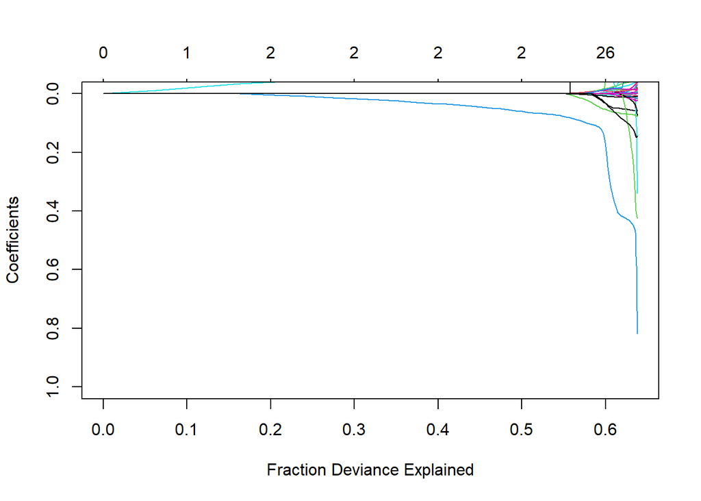

```r
Div_Win <- as.vector(train.data$DivWin)

train.data.predict <- model.matrix(~.-1,train.data[,-6])



DivWinfit <- glmnet(train.data.predict,Div_Win,family="binomial")

plot(DivWinfit,xvar ="dev",ylim=c(1,0))
```

3. [2 + 2 points] How many nonzero model coefficients are needed to explain 50% of the deviance? 60%? Which coefficients are these in each case?

```r
DivWinfit


DivWinfit50 <- coef(DivWinfit, s = 0.038030)

DivWinfit50 @ Dimnames[[1]][1 + DivWinfit50@i]



DivWinfit60 <- coef(DivWinfit, s = 0.001937)

DivWinfit60 @ Dimnames[[1]][1 + DivWinfit60@i]
```

```
Call:  glmnet(x = train.data.predict, y = Div_Win, family = "binomial")

   Df  %Dev   Lambda
1   0  0.00 0.244500
2   1  6.30 0.222800
3   1 11.67 0.203000
4   1 16.31 0.184900
5   2 20.45 0.168500
6   2 24.13 0.153500
7   2 27.40 0.139900
8   2 30.31 0.127500
9   2 32.92 0.116100
10  2 35.27 0.105800
11  2 37.38 0.096430
12  2 39.29 0.087860
```

[output cut: 92 more lines]

4. [2 + 1 points] Now use cross-validation to choose a moderately conservative model. State the variables you will include.

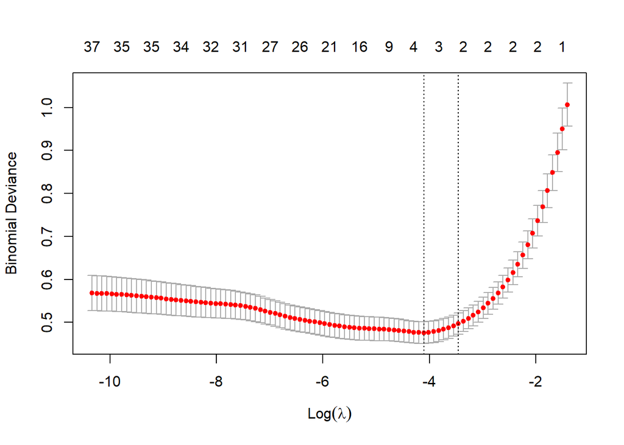

```r
set.seed(123)

DivWincv <- cv.glmnet(train.data.predict,Div_Win,family="binomial")
plot(DivWincv)
```

```r
DivWinmax <- coef(DivWinfit, s=DivWincv$lambda.min)
DivWinmax@Dimnames[[1]][1+DivWinmax@i]


mcm <-
  glm(DivWin ~ W + L + attendance, data = train.data, family = 'binomial')
```

```
[1] "(Intercept)" "W"           "L"           "attendance"
```

The variables we include are “W”,“L” and “attendance”.

5. [4 + 2 points] Fit the model on the training data, then predict on the testing data. Plot comparative ROC curves and summarise your findings.

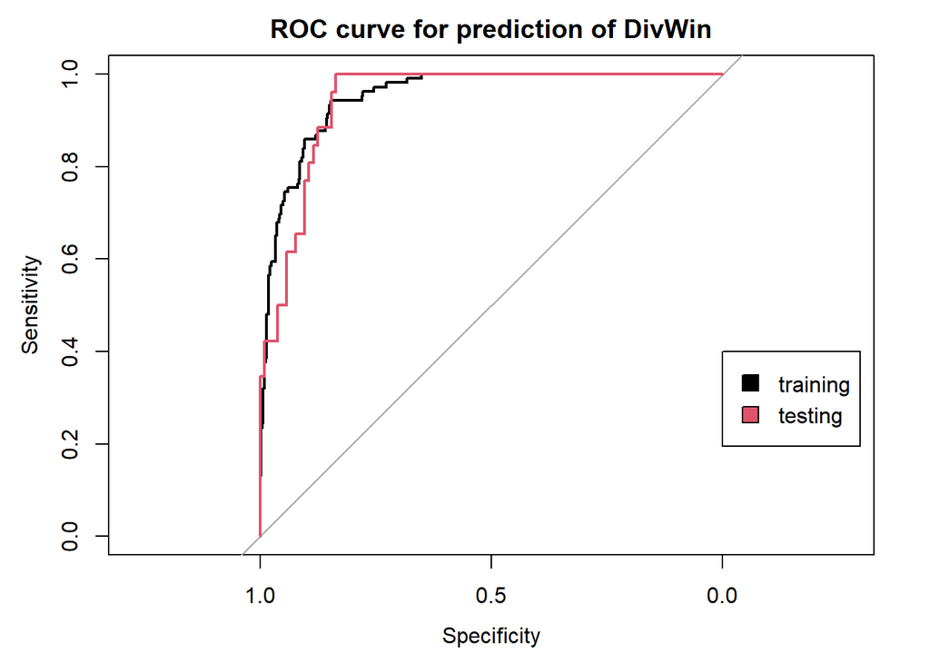

```r
train.model <- glm(DivWin ~ W + L + attendance, data = train.data, family = "binomial")


predtrain <- predict(train.model, type = "response")
predtest <- predict(train.model, newdata = test.data, type = "response")



roc.train <- roc(response = train.data$DivWin, predictor = predtrain, plot = TRUE, auc = TRUE, main = "ROC curve for prediction of DivWin")

roc.test<- roc(response = test.data$DivWin, predictor = predtest, plot = TRUE, auc = TRUE, add = TRUE, col = 2)

legend(0, 0.4, legend = c("training","testing"), fill = 1:2)
```

```r
roc.train$auc
roc.test$auc
```

```
Area under the curve: 0.9517
Area under the curve: 0.9442
```

The ROC curves of both training and testing have a very similar shape which means that this is a good sign that the data is not overfitted to the training data.

6. [4 + 2 points] Find Youden’s index for the training data and calculate confusion matrices at this cutoff for both training and testing data. Comment on the quality of the model for prediction in terms of false negative and false positive rates for the testing data.

```r
youden1<-coords(roc.train,"b",best.method="youden",transpose=TRUE)
youden1
youden1[2]+youden1[3]


train.data$predDivWin <- ifelse(predict(train.model, newdata = train.data, type = 'response')>= 0.1836071, 'Y', 'N')
table(train.data$predDivWin, train.data$DivWin)



test.data$predDivWin <- ifelse(predict(train.model, newdata = test.data, type = 'response')>= 0.1836071, 'Y', 'N')
table(test.data$predDivWin, test.data$DivWin)
```

```
  threshold specificity sensitivity
  0.1836071   0.8468900   0.9433962
specificity
   1.790286

      N   Y
  N 354   6
  Y  64 100

     N  Y
  N 87  1
  Y 17 25
```

7. [5 + 1 points] Calculate the sensitivity+specificity on the testing data as a function of divID and plot as a barchart. Is the prediction equally good for all divisions?

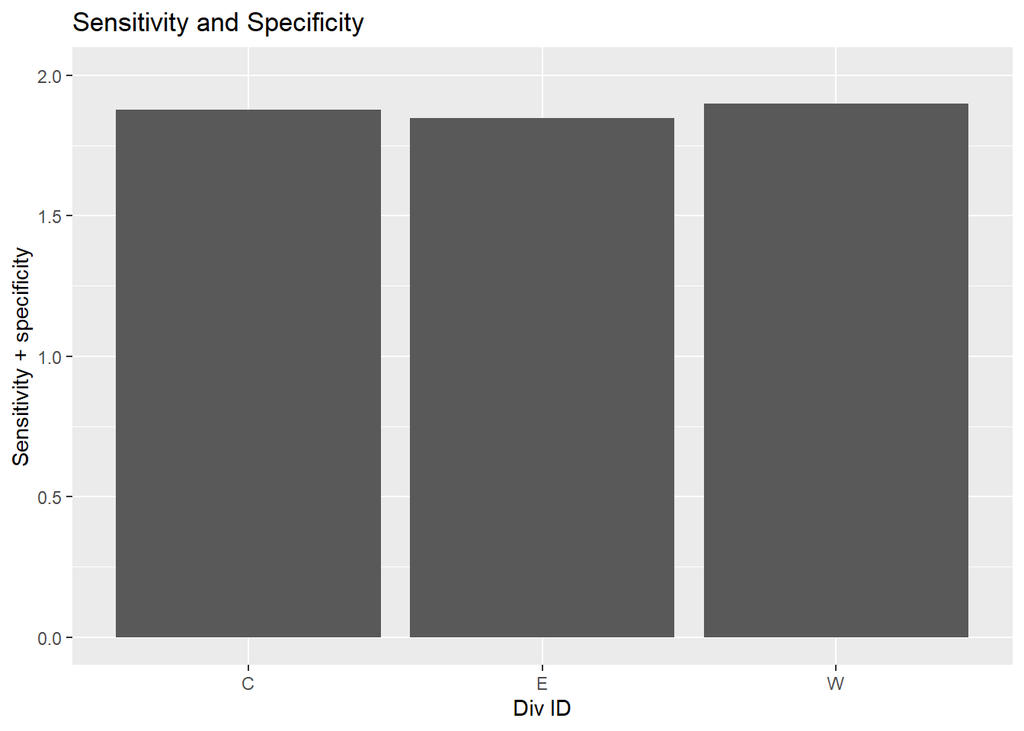

```
  threshold specificity sensitivity
  0.1571366   0.8780488   1.0000000
specificity
   1.878049

     N  Y
  N 36  1
  Y  5 11
  threshold specificity sensitivity
  0.4904867   0.8484848   1.0000000
specificity
   1.848485

     N  Y
  N 25  0
  Y  8  8
  threshold specificity sensitivity
  0.2980377   0.9000000   1.0000000
specificity
        1.9

     N  Y
  N 26  0
  Y  4  6
```

```r
divID1 <- Teamdata %>%
  rownames_to_column() %>%
  select(rowname,divID)


test.data1 <- test.data %>%
  rownames_to_column()

test.data1 <- test.data1 %>%
  left_join(divID1, by = c("rowname" = "rowname"), keep = FALSE)%>%
  mutate_at(vars(divID,DivWin), list(factor))




#Div ID for C

C <- test.data1 %>%
        filter(divID == "C")


preddivC <- predict(train.model, newdata = C, type = "response")

rocC <- roc(response = C$DivWin, predictor = preddivC, auc=TRUE)


youden2<-coords(rocC,"b", best.method="youden",transpose=TRUE)
youden2
yy2 <- youden2[2] + youden2[3]
yy2

C$predDivWinC <- ifelse(predict(train.model, newdata = C, type = "response") >=  0.1571366 , "Y", "N")
tableC <- table(C$predDivWin, C$DivWin)
tableC






#Div ID for E

E <- test.data1 %>%
        filter(divID == "E")


preddivE <- predict(train.model, newdata = E, type = "response")

rocE <- roc(response = E$DivWin, predictor = preddivE, auc=TRUE)


youden3<-coords(rocE,"b", best.method="youden",transpose=TRUE)
youden3
yy3 <- youden3[2] + youden3[3]
yy3


E$predDivWinE <- ifelse(predict(train.model, newdata = E, type = "response") >=   0.4904867  , "Y", "N")
tableE <- table(E$predDivWin, E$DivWin)
tableE





#Div ID for W

W <- test.data1 %>%
        filter(divID == "W")


preddivW <- predict(train.model, newdata = W, type = "response")

rocW <- roc(response = W$DivWin, predictor = preddivW, auc=TRUE)


youden4<-coords(rocW,"b", best.method="youden",transpose=TRUE)
youden4
yy4 <- youden4[2] + youden4[3]
yy4


W$predDivWinW <- ifelse(predict(train.model, newdata = W, type = "response") >=   0.2980377   , "Y", "N")
tableW <- table(W$predDivWin, W$DivWin)
tableW






plot<- data.frame(dev= c('C', 'E', 'W'), num = c(yy2, yy3, yy4))

ggplot(data = plot, aes(x = dev, y = num)) +
geom_col() +
ylim(0, 2) +
labs(x = 'Div ID',
y = 'Sensitivity + specificity',
title = 'Sensitivity and Specificity')
```

The predictions is almost the same for all the devisions and they seem pretty good.